# Fourth Week: Hypothesis Testing

TIMSS Analysis

Arefe Abghari

2018-03-08 22:38:17

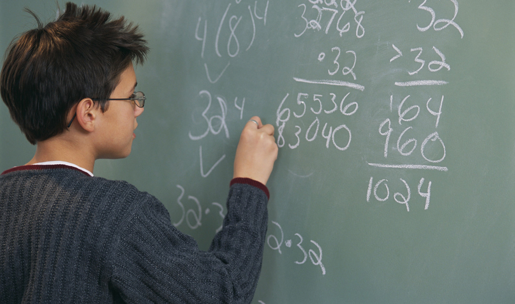

# تمرین سری چهارم: چقدر ریاضی بلدیم و چرا؟

لطفا مقاله زیر را مطالعه بفرمایید.

[چرایی رتبه ضعیف ایران در آزمون تیمز](https://goo.gl/gX8DZc)

> با استفاده از داده های ارزیابی تیمز ۲۰۱۵ ادعاهای زیر را مورد ارزیابی قراردهید. برای هر سوال علاوه بر استدلال آماری که در غالب آزمون فرض تعریف می شود از تصویرسازی مناسب باهر دو ابزار ggplot2 و highcharter استفاده نمایید. به دلخواه به هفت گزاره از موارد زیر پاسخ دهید.

۱. میران رضایت معلمان در پیشرفت تحصیلی دانش آموزان موثر است.

۲. والدینی که تحصیلات بیشتری دارند دارای فرزندان موفق تری می باشند.

میانگین تحصیلات والدین را به دست اورده ام و برای هر گروه میانگین نمرات را با تست $anova$ سنجیده ام همانطور که معلوم است چون میانگین ها تفاوت قابل توجهی دارند فرض صفر یعنب بی اثر بودن تحصیلات والدین روی موفقیت رد میشود.

```r
library(readr)
library(readxl)
library (tidyr)
library(dplyr)
```

```r
library(ggplot2)
library(highcharter)
bcg = read_rds("/Users/arefe/Desktop/Arefe/university/Data Analysis/timms/bcg.rds") # school background
bsg = read_rds("/Users/arefe/Desktop/Arefe/university/Data Analysis/timms/bsg.rds") # student background
btg = read_rds("/Users/arefe/Desktop/Arefe/university/Data Analysis/timms/btm.rds") # Teacher background
bsa = read_rds("/Users/arefe/Desktop/Arefe/university/Data Analysis/timms/bsa.rds") # strudent result
bst = read_rds("/Users/arefe/Desktop/Arefe/university/Data Analysis/timms/bst.rds") # student-teacher linkage
bsr = read_rds("/Users/arefe/Desktop/Arefe/university/Data Analysis/timms/bsr.rds") # within-country

cbind(
bsg%>%
  select (idstud , mother=bsbg07a , father=bsbg07b) %>%
  mutate(paredu=(mother+father)/2) ,
bsa %>%
  select ( bsmmat01:bsmmat05) %>%
  mutate(suc=(bsmmat01+bsmmat05+bsmmat02+bsmmat03+bsmmat04)/5)) %>%

  filter ( mother %in% 1:7 & father %in% 1:7) %>%
  select (paredu , suc) %>%
  arrange(paredu) ->students

students %>%
  group_by(paredu) %>%
  summarise(success=mean(suc)) ->stat


aov( success~ paredu, data = stat) -> fit
fit
```

```
## Call:
##    aov(formula = success ~ paredu, data = stat)
##
## Terms:
##                    paredu Residuals
## Sum of Squares  25338.191  1295.106
## Deg. of Freedom         1        11
##
## Residual standard error: 10.85067
## Estimated effects may be unbalanced
```

```r
summary.aov(fit)
```

```
##             Df Sum Sq Mean Sq F value   Pr(>F)
## paredu       1  25338   25338   215.2 1.44e-08 ***
## Residuals   11   1295     118
## ---
## Signif. codes:  0 '***' 0.001 '**' 0.01 '*' 0.05 '.' 0.1 ' ' 1
```

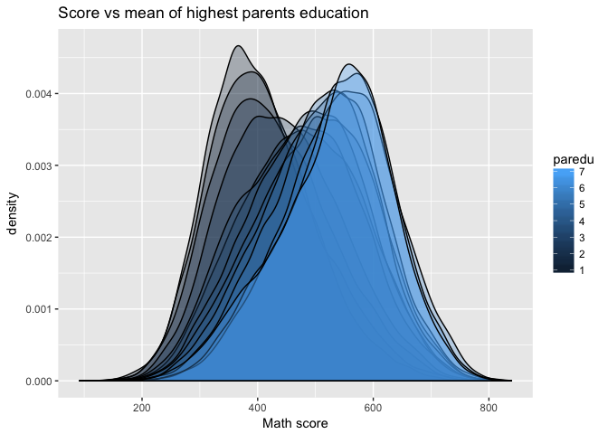

```r
students$suc = as.double(students$suc)
students$paredu = as.double(students$paredu)
students %>%
  ggplot(aes(x = suc, group=paredu, fill=paredu)) +
  geom_density(alpha = 0.3) +xlab("Math score") +ggtitle("Score vs mean of highest parents education")
```

۳. امکانات رفاهی در خانه موجب پیشرفت تحصیلی می گردد.

۴. محیط آرام مدرسه نقش مهمی در پیشرفت تحصیلی دارد.

۵. معلمان با تحصیلات بالاتر یا تجربه بیشتر دانش آموزان موفق تری تربیت می کنند.

۶. پسران در کاربرد هندسه قوی تر هستند.

از تی تست استفاده کرده ام و چون مقدار $p-value$ کم تر از ۰.۰۵ نیست اید فرض صفر که میانگین این دو گروه با هم برابر است رد نمی شود

```r
tims = read_rds("/Users/arefe/Desktop/Arefe/university/Data Analysis/timms/timss_2015.rds")
tims %>%
  filter (cognitive_domain=="Applying" & content_domain=="Geometry" ) %>%
  select(female = correct_ratio_per_question_female,
                  male = correct_ratio_per_question_male) %>%
  tidyr::gather("female","male", key = "gender",value = "score") -> dscore

dscore %>% group_by(gender) %>% summarise(mean = mean(score) %>% round(3)) %>%
  hchart("column",hcaes(x = gender,y = mean), name = "score") %>%
  hc_size(height = 300,width = 600) %>% hc_add_theme(hc_theme_ffx())
```

[interactive chart not shown]

```r
hypo = t.test(score~gender, data = dscore)
print(hypo)
```

```
##
##  Welch Two Sample t-test
##
## data:  score by gender
## t = 0.23614, df = 1493.7, p-value = 0.8134
## alternative hypothesis: true difference in means is not equal to 0
## 95 percent confidence interval:
##  -0.01907826  0.02430046
## sample estimates:
## mean in group female   mean in group male
##            0.4112235            0.4086124
```

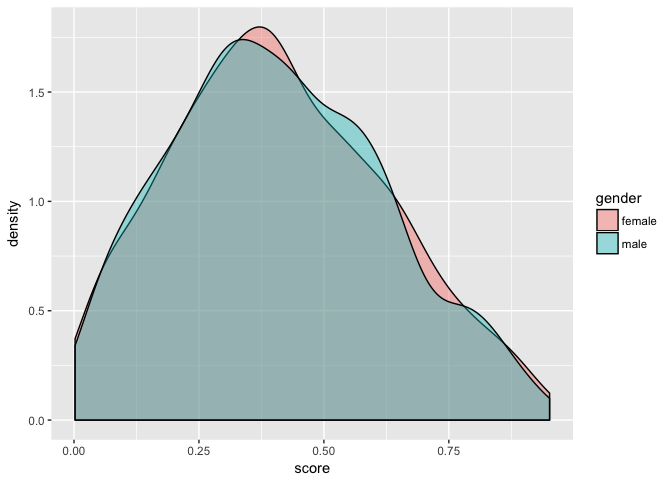

```r
ggplot(dscore,aes(x = score,fill = gender)) +
  geom_density(alpha= 0.4)
```

۷. تغذیه دانش آموزان نقش اساسی در یادگیری آنها دارد.

۸. مدارس با امکانات بیشتر دارای عملکرد بهتری می باشند.

۹. علت افت تحصیلی عدم مشارکت در کلاس است.

۱۰. دانش آموزان ایرانی در استدلال قوی تر از کاربرد هستند.

#### پاسخ

به وسیله تی تست این موضوع را ازمایش کرده ام و به نظر میرسد که این ادعا درست نیست

```r
library(readr)
library(readxl)
library (tidyr)
library(dplyr)
library(ggplot2)
library(highcharter)
tims = read_rds("/Users/arefe/Desktop/Arefe/university/Data Analysis/timms/timss_2015.rds")



tims%>%
  filter(Country=="Iran, Islamic Rep. of") %>%
  filter (cognitive_domain=="Reasoning" | cognitive_domain=="Applying") %>%
  select (cognitive_domain , score=correct_ratio_per_question)->iran


hypo = t.test(score ~ cognitive_domain , data = iran , alt="greater")

print(hypo)
```

```
##
##  Welch Two Sample t-test
##
## data:  score by cognitive_domain
## t = 2.6374, df = 90.055, p-value = 0.00492
## alternative hypothesis: true difference in means is greater than 0
## 95 percent confidence interval:
##  0.02566765        Inf
## sample estimates:
##  mean in group Applying mean in group Reasoning
##               0.3233984               0.2540000
```

```r
iran %>%
  group_by(cognitive_domain) %>% summarise(mean = mean(score) %>% round(3)) %>%
  hchart("column",hcaes(x = cognitive_domain,y = mean), name = "score") %>%
  hc_size(height = 300,width = 600) %>% hc_add_theme(hc_theme_ffx())
```

[interactive chart not shown]

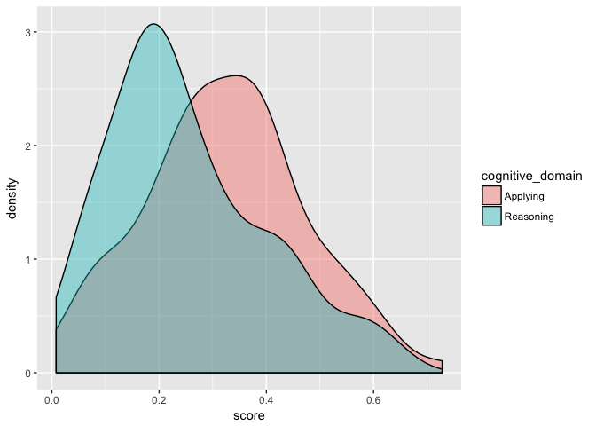

```r
ggplot(iran,aes(x = score,fill = cognitive_domain)) +
  geom_density(alpha= 0.4)
```

***

سه گزاره جالب کشف کنید و ادعای خود را ثابت نمایید.